# Prostate Cancer RNASeq Analysis Between African Americans and Causasian Americans:

Flemming Wu

### Load libraries

```r
library(readxl)
library(openxlsx)
library(magrittr)
library(purrr)
library(dplyr)
library(tidyr)
library(tibble)
library(stringr)
library(RUVSeq)
library(ggplot2)
library(RColorBrewer)
library(DESeq2)
library(EnsDb.Hsapiens.v86)
library(EnhancedVolcano)
library(clusterProfiler)
library(org.Hs.eg.db)
library(ggpubr)
library(msigdbr)
```

### Read in and process data

```r
metadata <- read_xlsx("./data/RNAseq_Samples_012723.xlsx")
data <- read_xlsx("./data/Data_012723.xlsx")
```

```r
dim(data) #58780 genes in 20 samples
```

Set gene id to row names and remove redundant columns

```r
#head(data) ## gene id columns are redundant, make them the rownames and remove columns
data <- column_to_rownames(data, var = "Geneid...1")
data <- dplyr::select(data, -starts_with("Geneid"))
```

Rename columns so they are easier to work with downstream

```r
new.names <- metadata %>%
  mutate(KGP_Sample_ID = stringr::str_extract(KGP_Sample_ID, "00[:digit:]{2}") %>%
           stringr::str_replace("00[0]?", "RNA")) %>%
  mutate(`Tissue Type` = ifelse(`Tissue Type` == "Malignant", "M", "N"),
                Race = ifelse(Race == "Black", "B", "W")) %>%
  tidyr::unite(id, c("Tissue Type", "Race", "MGC_Sample_ID")) %>%
  arrange(as.integer(str_extract(KGP_Sample_ID, "[:digit:]{1,2}"))) %>%
  dplyr::select(id) %>%
  as.list()

names(data) <- new.names$id
```

### Split data by comparisons

*reference level (control) in design matrix is the first level of the factor variable, which is the level with the lowest number or letter among the values provided*

Since the reference group in the design matrix is assigned by the level with the lowest number or letter among the values provided, I named the groups to match accordingly.

```r
#head(table(rowMeans(data)), 20)
#head(table(rowSums(data)), 20) # 18,082 genes have 0 expression across all samples

## split data for all comparisons

# Nonnmalignant black vs malignant black
mb_nb <- data %>% select_if(grepl("M_B", names(.)) | grepl("N_B", names(.)))
# Walignant white vs nonmalignant black
mw_nb <- data %>% select_if(grepl("M_W", names(.)) | grepl("N_B", names(.)))
# Nonmalignant black vs nonmalignant white
nb_nw <- data %>% select_if(grepl("N_B", names(.)) | grepl("N_W", names(.)))
# Malignant black vs malignant white
mb_mw <- data %>% select_if(grepl("M_B", names(.)) | grepl("M_W", names(.)))
# Malignant black vs nonmalignant white
mb_nw <- data %>% select_if(grepl("M_B", names(.)) | grepl("N_W", names(.)))
# Malignant white vs nonmalignant white
mw_nw <- data %>% select_if(grepl("M_W", names(.)) | grepl("N_W", names(.)))

## combine into list of datasets
all.dfs <- list("mb_nb" = mb_nb, "mw_nb" = mw_nb, "nb_nw" = nb_nw, "mb_mw" = mb_mw, "mb_nw" = mb_nw, "mw_nw" = mw_nw)
```

### Remove unwanted variation with `RUVg`

First, filter out rows that don’t meet the requirements of: more than 5 reads in at least 3 samples from each comparison

```r
all.dfs.filt <- lapply(all.dfs, function(df) df[apply(df, 1, function(x) length(x[x>5])>=3), ])
```

Create SeqExpressionSet objects from data frames

```r
make_sets <- function(df) {
  x <- names(df) %>% str_extract("[MN]_[WB]") %>% as.factor()
  set <- newSeqExpressionSet(as.matrix(df), phenoData = data.frame(x, row.names = colnames(df)))
  return(set)
}

all.sets <- lapply(all.dfs.filt, function(x) make_sets(x))
```

#### EDA

View PCA and RLE plots of the samples prior to normalization

```r
plot_sets <- function(set) {
  x <- set$x
  colors <- brewer.pal(3, "Set1")
  plotRLE(set, outline = FALSE, ylim = c(-4,4), col = colors[x])
  plotPCA(set, col = colors[x], cex = 0.7)
}

#lapply(all.sets, function(set) plot_sets(set)) ## check plots
```

#### Run between lane (upper quartile) normalization.

```r
all.sets.norm <- lapply(all.sets, function(set) betweenLaneNormalization(set, which = "upper"))

#lapply(all.sets.norm, function(set) plot_sets(set)) ## check new plots
```

### Create empirical negative control genes and Run DE analysis with `edgeR`

#### Since no genes are known a priori to be influenced by covariates of interest, I will use least significantly DE genes as “in-silico empirical” negative controls.

```r
## write function to update SeqExpressionSet objects to have negative controls
est_neg_ctrl <- function(set) {
  x <- set$x
  design <- model.matrix(~x, data = pData(set))
  y <- DGEList(counts = counts(set), group = x)
  y <- calcNormFactors(y, method = "upperquartile")
  y <- estimateGLMCommonDisp(y, design)
  y <- estimateGLMTagwiseDisp(y, design)

  fit <- glmFit(y, design)
  lrt <- glmLRT(fit, coef = 2)

  top <- topTags(lrt, n = nrow(set))$table
  empirical <- rownames(set)[which(!(rownames(set) %in% rownames(top)[1:5000]))]

  # run RUVg
  newset <- RUVg(set, empirical, k = 1)
  return(newset)
}

## Function to rerun edgeR with newly obtained negative controls
run_glmLRT <- function(newset) {
  x <- newset$x
  design <- model.matrix(~x + W_1, data = pData(newset))
  y <- DGEList(counts = counts(newset), group = x)
  y <- calcNormFactors(y, method = "upperquartile")
  y <- estimateGLMCommonDisp(y, design)
  y <- estimateGLMTagwiseDisp(y, design)

  fit <- glmFit(y, design)
  lrt <- glmLRT(fit, coef=2)
  return(lrt)
}


################



all.sets.norm.nc <- lapply(all.sets.norm, est_neg_ctrl)
all.res <- lapply(all.sets.norm.nc, run_glmLRT) ## all.res stores final edgeR results
```

Filter gene lists based on: p-val= 0.05, p-val= 0.01, p-val= 0.001, FDR: 10%

```r
filterResults <- function(dgelrt, filt, thresh){
  topTags(dgelrt, sort.by = "p.value", n = nrow(dgelrt), adjust.method = "BH") %>%
  as.data.frame() %>%
  filter(if (filt == "pval") PValue < thresh else FDR < thresh)
}

genes.p05 <- lapply(all.res, filterResults, "pval", 0.05)
genes.p01 <- lapply(all.res, filterResults, "pval", 0.01)
genes.p001 <- lapply(all.res, filterResults, "pval", 0.001)
genes.fdr1 <- lapply(all.res, filterResults, "logfc", 0.1)
```

Add gene symbol to results

```r
addGeneSym <- function(df) {
  # remove "." from ensembl gene id
  rownames(df) <- sub("\\.[0-9]*$", "", rownames(df))
  # map ensembl geneid to gene symbol
  geneids <- ensembldb::select(x = EnsDb.Hsapiens.v86,  key=rownames(df), columns=c("SYMBOL"), keytype="GENEID")
  rownames(geneids) <- geneids$GENEID

  # merge mapping back to original dataframe
  df <- merge(x = df, y = geneids, by = "row.names", all = TRUE) %>%
    column_to_rownames(var = "Row.names") %>%
    relocate(SYMBOL, .before = logFC) %>%
    select(!starts_with("GENEID"))

  return(df)
}


genes.p05 <- lapply(genes.p05, addGeneSym)
genes.p01 <- lapply(genes.p01, addGeneSym)
genes.p001 <- lapply(genes.p001, addGeneSym)
genes.fdr1 <- lapply(genes.fdr1, addGeneSym)
```

Write results to excel workbook

```r
all.filtered.gene.lists <- list("p0.05" = genes.p05, "p0.01" = genes.p01, "p0.001" = genes.p001, "fdr0.1" = genes.fdr1)

## function to write gene lists to excel
write_results <- function(list_of_datasets){
  mb_nb.res <- list()
  mw_nb.res <- list()
  nb_nw.res <- list()
  mb_mw.res <- list()
  mb_nw.res <- list()
  mw_nw.res <- list()


  for (i in names(list_of_datasets)){
    for (j in names(list_of_datasets[[i]])){
      if (j == "mb_nb"){
        mb_nb.res[[i]] <- list_of_datasets[[i]][[j]]
      } else if (j == "mw_nb"){
        mw_nb.res[[i]] <- list_of_datasets[[i]][[j]]
      } else if (j == "nb_nw"){
        nb_nw.res[[i]] <- list_of_datasets[[i]][[j]]
      } else if (j == "mb_nb"){
        mb_nb.res[[i]] <- list_of_datasets[[i]][[j]]
      } else if (j == "mb_mw"){
        mb_mw.res[[i]] <- list_of_datasets[[i]][[j]]
      } else if (j == "mb_nw"){
        mb_nw.res[[i]] <- list_of_datasets[[i]][[j]]
      } else if (j == "mw_nw"){
        mw_nw.res[[i]] <- list_of_datasets[[i]][[j]]
      }
    }
  }
  return(list("mb_nb" = mb_nb.res, "mw_nb" = mw_nb.res, "nb_nw" = nb_nw.res,
         "mb_mw" = mb_mw.res, "mb_nw" = mb_nw.res, "mw_nw" = mw_nw.res))
}
```

```r
to_write <- write_results(all.filtered.gene.lists)

invisible(lapply(names(to_write), function(name) {
  write.xlsx(to_write[[name]], file = paste0("./filtered_gene_lists/", name, ".xlsx"), rowNames = T)
  }
))
```

## Gene Set Enrichment Analysis

GO and KEGG are the most frequently used for functional analysis. They are typically the first choice because of their long-standing curation and availability for a wide range of species.

- Typically, GSEA is run on all genes, not only over/under expressed genes. This information will be taken care of by providing GSEA a **ranked** list of genes.
- Important that the result is not that a specific pathway that is up- or down-regulated, but the fact that the pathway is affected in some way by the condition that you are studying.
  - https://www.biostars.org/p/449956/
- The GSEA algorithm does not filter the expression dataset and generally does not benefit from your filtering of the expression dataset. During the analysis, genes that are poorly expressed or that have low variance across the dataset populate the middle of the ranked gene list and the use of a weighted statistic ensures that they do not contribute to a positive enrichment score. By removing such genes from your dataset, you may actually reduce the power of the statistic.

### First I will perform gene set enrichment analysis on GO terms.

```r
## first step of GSEA is to rank your entire list of genes
## this can be done by multiplying the logFC by -10log(pval) to account for both expression level and significance

all.tables <- lapply(all.res, function(x) topTags(x, n = nrow(x), adjust.method = "BH"))

makeGeneLists <- function(x) {
  x %>%
    as.data.frame() %>% mutate(stat = logFC * -log10(PValue)) %>%
    rownames_to_column(var = "ENSEMBL") %>%
    mutate(ENSEMBL = str_replace(ENSEMBL, ".[0-9]{1,2}$", "")) %>%
    dplyr::select(ENSEMBL, stat) %>%
    arrange(-stat) %>%
    tibble::deframe()
}


all.geneLists <- lapply(all.tables, makeGeneLists)
```

```r
all.gsea <- lapply(all.geneLists, function(x) gseGO(geneList = x, OrgDb = org.Hs.eg.db, keyType = "ENSEMBL", minGSSize = 100, maxGSSize = 500,  nPermSimple = 10000, pvalueCutoff = 1, verbose = F, eps = 1e-300))
```

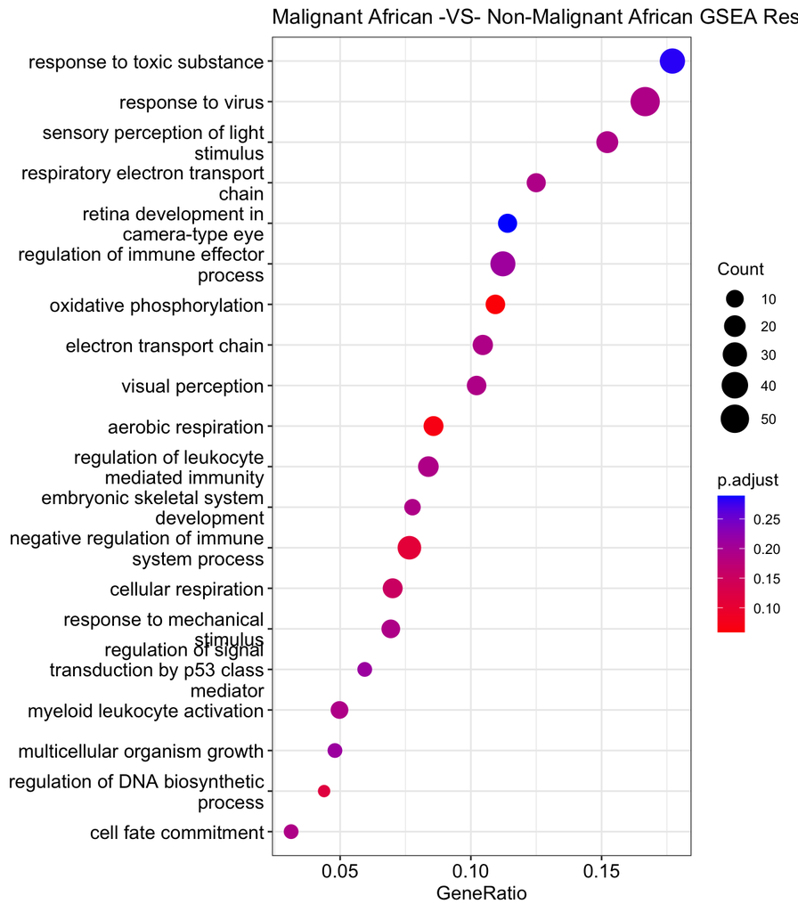

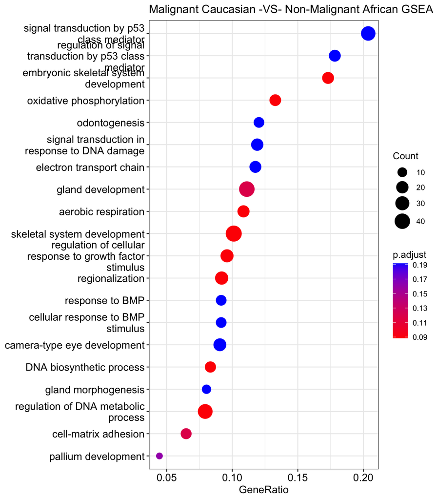

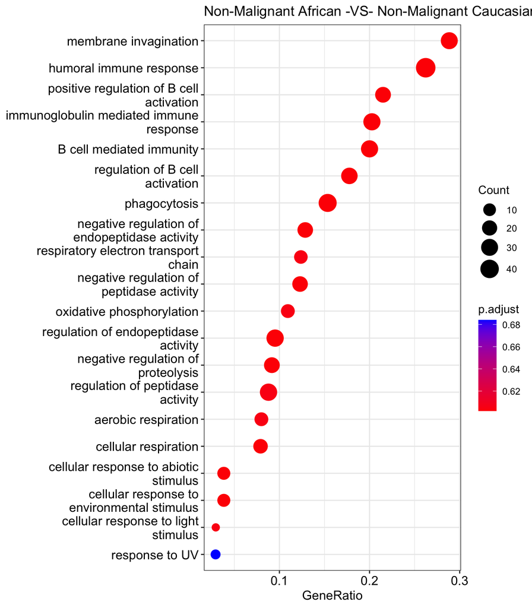

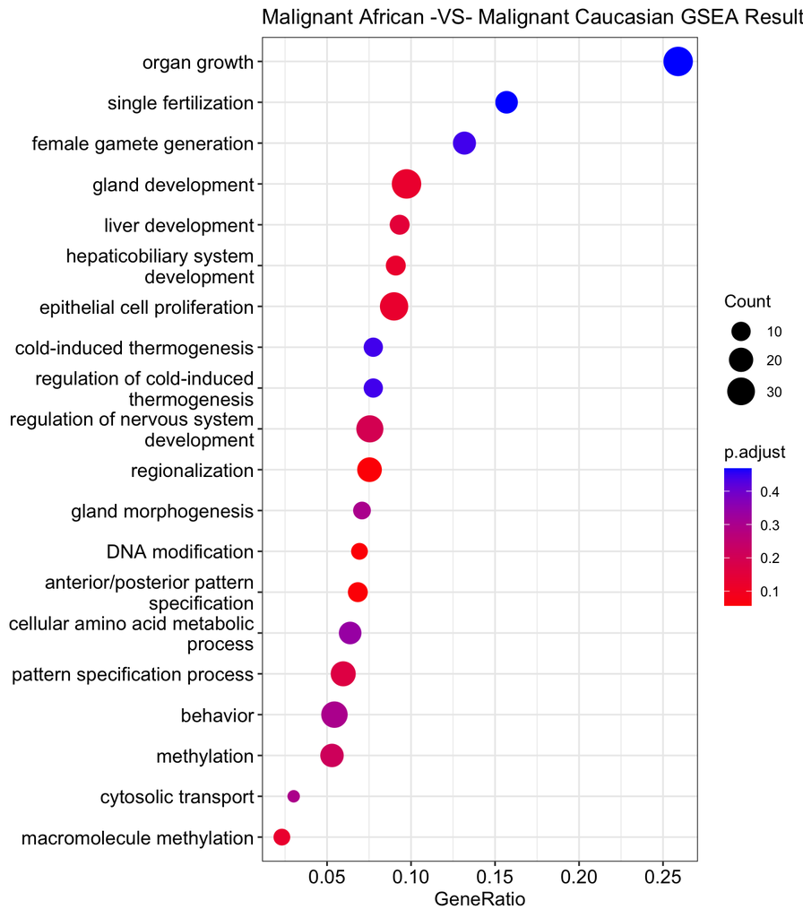

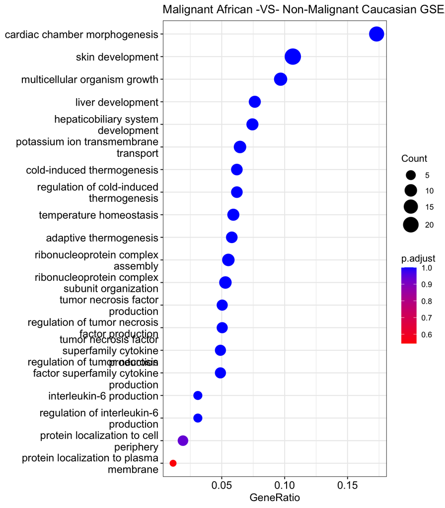

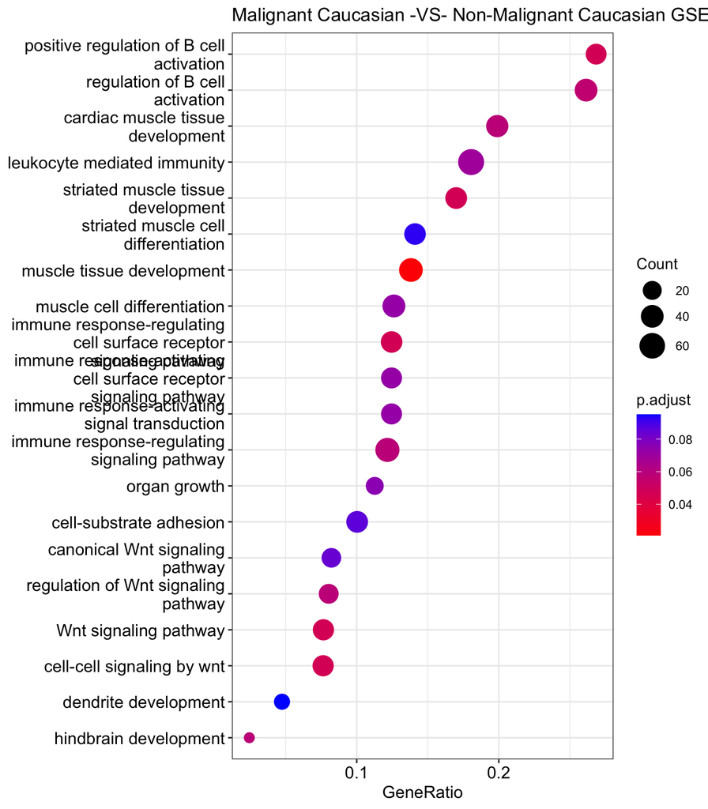

```r
#lapply(all.gsea, function(x) as.data.frame(x))
lapply(names(all.gsea), function(x) dotplot(all.gsea[[x]], showCategory=20, title = paste(x %>%
                    str_replace_all("n", "Non-Malignant ") %>%
                    str_replace_all("m", "Malignant ") %>%
                    str_replace_all("b", "African") %>%
                    str_replace_all("w", "Caucasian") %>%
                    str_replace_all("_", " -VS- "), "GSEA Results")) + scale_y_discrete(labels = function(x) stringr::str_wrap(x, width = 30)))
```

```r
# write separate files for each comparison
invisible(lapply(names(all.gsea), function(x){
  write.xlsx(all.gsea[[x]],
             file = paste0("./gene_set_enrichment_analysis_results/", x, ".xlsx"))
  }
))
```

## Pathway enrichment analysis (over representation analysis)

Pathway enrichment analysis is done on differentially expressed genes, typically filtered by p-value and logFC. It tests the probability of your genes matching a gene set, against the probability of matching the gene set at random.

First, separate the filtered gene lists into upregulated and downregulated genes.

```r
## separate list of up and down regulated genes
genes.p05up <- lapply(genes.p05, function(x) filter(x, logFC > 0))
genes.p05dn <- lapply(genes.p05, function(x) filter(x, logFC < 0))
genes.p01up <- lapply(genes.p01, function(x) filter(x, logFC > 0))
genes.p01dn <- lapply(genes.p01, function(x) filter(x, logFC < 0))
genes.p001up <- lapply(genes.p001, function(x) filter(x, logFC > 0))
genes.p001dn <- lapply(genes.p001, function(x) filter(x, logFC < 0))
genes.fdr1up <- lapply(genes.fdr1, function(x) filter(x, logFC > 0))
genes.fdr1dn <- lapply(genes.fdr1, function(x) filter(x, logFC < 0))
```

Write functions to take gene lists an input and run an over representation analysis against a specified database. Here, I will be using GO (gene ontology database) and the H (hallmark) and C6 (oncogenic gene set) from MSigDb (molecular signatures database).

```r
## function to run over representation analysis on GO database
runenrichGO <- function(x){
  enrichGO(gene = AnnotationDbi::select(org.Hs.eg.db, keys = rownames(x), columns='ENTREZID', keytype='ENSEMBL') %>% pull(ENTREZID), ont = "ALL", OrgDb = org.Hs.eg.db, readable = TRUE)
}


## prepare dataframe for MSigDb search
hmk <- msigdbr::msigdbr(species = "Homo sapiens", category = "H") %>% dplyr::select(gs_name, entrez_gene)
C6 <- msigdbr::msigdbr(species = "Homo sapiens", category = "C6") %>% dplyr::select(gs_name, entrez_gene)
m_df <- rbind(hmk, C6) ## I will search against Hallmark Gene Set and Oncogene Set


## function to run over representation analysis on Molecular Signatures Database
runMsigdbEnricher <- function(x){
  enricher(AnnotationDbi::select(org.Hs.eg.db, keys = rownames(x), columns='ENTREZID', keytype='ENSEMBL') %>% pull(ENTREZID), TERM2GENE = m_df)
}
```

#### Run over representation analysis

```r
## create list to hold all filtered gene lists (up and down regulated)
filtered.geneLists <- list("genes.p05up" = genes.p05up, "genes.p05dn" = genes.p05dn, "genes.p01up" = genes.p01up, "genes.p01dn" = genes.p01dn, "genes.p001up" = genes.p001up, "genes.p001dn" = genes.p001dn, "genes.fdr1up" = genes.fdr1up, "genes.fdr1dn" = genes.fdr1dn)


## run analysis on over representated pathways in GO and MSigDb
all.ego.res <- lapply(filtered.geneLists, function(y) lapply(y, runenrichGO))
all.msigdb.res <- lapply(filtered.geneLists, function(y) lapply(y, runMsigdbEnricher))
## split results into their respective comparisons (ex: Malignant African vs Nonmalignant African)
msigdb_to_write <- write_results(all.msigdb.res)
ego_to_write <- write_results(all.ego.res)


## each excel sheet will contain all pathway analysis results for one comparison
## the tabs on each sheet will be separated by filtering and whether an upregulated or downregulated list was used for the comparison (ex: p < 0.01, upregulated gene list)

invisible(lapply(names(msigdb_to_write), function(name) {
  write.xlsx(msigdb_to_write[[name]], file = paste0("./MSigDb_ORA_results/", name, ".xlsx"), rowNames = T)
  }
))

invisible(lapply(names(msigdb_to_write), function(name) {
  write.xlsx(msigdb_to_write[[name]], file = paste0("./GO_ORA_results/", name, ".xlsx"), rowNames = T)
  }
))
```

## Volcano Plots

```r
makeTables <- function(dgelrt){
  topTags(dgelrt, sort.by = "p.value", n = nrow(dgelrt), adjust.method = "BH") %>%
  as.data.frame()
}


all.tables.sym <- lapply(all.res, makeTables)
all.tables.sym <- lapply(all.tables.sym, addGeneSym)
```

```r
DoVolcanoPlot <- function(x){
  EnhancedVolcano(all.tables.sym[[x]],
                  x = "logFC",
                  y = "PValue",
                  lab = all.tables.sym[[x]]$SYMBOL,
                  title = x %>%
                    str_replace_all("n", "Non-Malignant ") %>%
                    str_replace_all("m", "Malignant ") %>%
                    str_replace_all("b", "African") %>%
                    str_replace_all("w", "Caucasian") %>%
                    str_replace_all("_", " -VS- "),
                  subtitle = "p-value cutoff: 0.05 | log2-fold change cutoff: 1",
                  col = c("gray", "#4bd0fe", "red1", "#fef84b")
  )
}

volplots <- lapply(names(all.tables.sym), DoVolcanoPlot)
names(volplots) <- names(all.tables.sym)
```

## MA Plots

Typically, lower mean expression values will have more variability in log fold-change than the higher expression value. This results in a fanning effect of the data points as the graph moves from right to left.

```r
DoMAPlot <- function(x){
  data <- all.tables.sym[[x]] %>%
    rename(log2FoldChange = logFC, baseMeanLog2 = logCPM, padj = PValue)
  genenames <- all.tables.sym[[x]]$SYMBOL %>% as.vector()
  ggmaplot(data = data,
           main = x %>%
             str_replace_all("n", "Non-Malignant ") %>%
             str_replace_all("m", "Malignant ") %>%
             str_replace_all("b", "African") %>%
             str_replace_all("w", "Caucasian") %>%
             str_replace_all("_", " -VS- "),
           fdr = 0.05, fc = 2, size = 0.4,
           palette = c("#7AFF96", "#FF7A7A", "darkgray"),
           genenames = genenames,
           legend = "top", top = 20,
           select.top.method = "padj",
           font.label = c("bold", 9), label.rectangle = FALSE,
           font.legend = "bold",
           font.main = "bold",
           xlab = "Average logCPM",
           ggtheme = ggplot2::theme_minimal()
           )
}

maplots <- lapply(names(all.tables.sym), DoMAPlot)
names(maplots) <- names(all.tables.sym)
```

## DESeq2

Try to run DESeq2 out of curiosity

```r
run_DESeq <- function(set) {
  x <- set$x
  dds <- DESeqDataSetFromMatrix(countData = counts(set), colData = pData(set), design = ~W_1 + x)
  dds <- DESeq(dds)
  res <- results(dds)
  return(res)
}

all.deseq.res <- lapply(all.sets.norm.nc, run_DESeq)

## convert to data frame
#all.deseq.res <- lapply(all.deseq.res, as.data.frame)

## add gene symbols
#all.deseq.res.sym <- lapply(all.deseq.res, add_gene_sym)

#lapply(names(all.deseq.res.sym), function(x) EnhancedVolcano(all.deseq.res.sym[[x]], x = "log2FoldChange", y = "padj", lab = all.deseq.res.sym[[x]]$SYMBOL,
#                                                       title = x %>%
#                                                         str_replace_all("n", "Non-Malignant ") %>%
#                                                         str_replace_all("m", "Malignant ") %>%
#                                                         str_replace_all("b", "African") %>%
#                                                         str_replace_all("w", "Caucasian") %>%
#                                                         str_replace_all("_", " -VS- "),
#                                                       subtitle = "p-value cutoff: 0.05 | log2-fold change cutoff: 1", col = c("gray", "red2", "yellow1", "blue3")
#                                                      ))
```